# Final Project 131

Yuanning Li

2022-11-08

## Introduction change

The aim of the project is to analyze the population trend among the world from 1970s to 2020s, and research about which model can best fit on the population data and predict and population. I use data from $Kaggle$ and implement several techniques to answer the questions about population, growth rate, country areas, etc. I am also interested in fitting models on current data to predict the trend.

## Loading Packages and Setting Up The Environment

This project uses data from $Kaggle$ which records the population, land area, population density, etc. of 234 countries.

```r
library(tidyverse)   # using tidyverse and tidymodels for this project mostly
library(tidymodels)
library(ggplot2)   # for most of our visualizations
library(rpart.plot)  # for visualizing trees
library(randomForest)   # for building our randomForest
```

```r
# import data
df <- read.csv('world_population.csv')
head(df)
```

```
##   Rank CCA3 Country.Territory          Capital Continent X2022.Population
## 1   36  AFG       Afghanistan            Kabul      Asia         41128771
## 2  138  ALB           Albania           Tirana    Europe          2842321
## 3   34  DZA           Algeria          Algiers    Africa         44903225
## 4  213  ASM    American Samoa        Pago Pago   Oceania            44273
## 5  203  AND           Andorra Andorra la Vella    Europe            79824
## 6   42  AGO            Angola           Luanda    Africa         35588987
##   X2020.Population X2015.Population X2010.Population X2000.Population
## 1         38972230         33753499         28189672         19542982
## 2          2866849          2882481          2913399          3182021
## 3         43451666         39543154         35856344         30774621
## 4            46189            51368            54849            58230
## 5            77700            71746            71519            66097
## 6         33428485         28127721         23364185         16394062
##   X1990.Population X1980.Population X1970.Population Area..km..
## 1         10694796         12486631         10752971     652230
## 2          3295066          2941651          2324731      28748
## 3         25518074         18739378         13795915    2381741
## 4            47818            32886            27075        199
## 5            53569            35611            19860        468
## 6         11828638          8330047          6029700    1246700
##   Density..per.km.. Growth.Rate World.Population.Percentage
## 1           63.0587      1.0257                        0.52
## 2           98.8702      0.9957                        0.04
## 3           18.8531      1.0164                        0.56
## 4          222.4774      0.9831                        0.00
## 5          170.5641      1.0100                        0.00
## 6           28.5466      1.0315                        0.45
```

# DATA DESCRIPTION

`Rank`=“Rank of Popluation”

`CCA3`=“3 Digit Country/Territories Code”

`Country`=“Name of the Country/ Territories”

`Capital`=“Name of the Capital”

`Continent`=“Name of the Continent”

`2022_Population`=“Population of the Country/Territories in the year 2022”

`2020_Population`=“Population of the Country/Territories in the year 2020”

`2015_Population`=“Population of the Country/Territories in the year 2015”

`2010_Population`=“Population of the Country/Territories in the year 2010”

`2000.Population`=“Population of the Country/Territories in the year 2000”

`1990_Population`=“Population of the Country/Territories in the year 1990”

`1980_Population`=“Population of the Country/Territories in the year 1980”

`1970_Population`=“Population of the Country/Territories in the year 1970”

`Area`=“Area size of the Country/Territories in square kilometer”

`Density`=“Population Density per square kilometer”

`Growth_Rate`=“Population Growth Rate by Country/Territories”

`World_Population_Percentage`=“The Population percentage by each Country/Territories”

Note: a full copy of the codebook is available in text files

### What is the current state of the world population?

In June 2019, the world population estimate surveyed by the U.S. Census Bureau showed that the current global population is 757,713,040 people, which is much higher than the world population of 7.2 billion in 2015. It seems that the earth is very crowded and the population is still growing very fast.

### Why is analyzing and modeling the population so important?

For a growing population, since the resources on our planet are limited, the more the population, the greater the demand for various resources. When the world’s population reaches a certain number, resources will be exhausted, and the loss of resources may lead to the destruction of the earth! So I hope these analysis and models can help us understand the current population situation and take corresponding measures to maintain the earth.

### Project pathway

Knowing the background and the importance of the topic, I’d like to discuss how to analyze and build models. First I do some initial data manipulation and cleaning on the original data. Then I explore the data and see if there’s any interesting findings about population, density, area in time series and continent perspective.

At the end, I use existing data from previous years to make the prediction. I’ll split and resample the data, build the recipe and workflow, and train the model. Because this is a regression problem, I choose Ridge regression, Lasso regression, regression tree, and random forest these four models. I’d like to find the best parameters for our model using cross validation, and find which of the four models perform the best on our test dataset.

## Clean Data

Our original data is quite clean, so there’s not much data cleaning to do. I simply renamed the feature names to make it more clean.

```r
# renamed all of the columns to make column names more clean and neat
colnames(df) <- c('Rank', 'CCA3', 'Country','Capital','Continent','Population_2022',
                  'Population_2020','Population_2015','Population_2010',
                  'Population_2000','Population_1990','Population_1980',
                  'Population_1970','Area', 'Density', 'Growth_Rate',
                  'World_Population_Percentage')
```

## EDA

The entire exploratory data analysis will be based on the entire data set with 234 observations. Each observation represents the data of a country.

### Key Takeaways

##### – What are the countries with largest and smallest population in the world? Is China going to remain the Top 1 population country in the world in the future?

##### – Are the countries with small density / population has smaller growth rate than those countries with large density / population?

##### – In the continent perspective, which continent has largest population and density? What is the trend?

##### – What are the largest and smallest countries in size?

The EDA part will answer the above questions.

First extract the top five countries by population from 1970 to 2022.

```r
# for EDA, no need for more dropping or cleaning, we will clean later for model
# add column for growth rate??
# EDA
# 1. Top 5 populous countries in 1970, 1980, 1990, 2000, 2010, 2015, 2020 and 2022.
df1 <- df
colnames(df1) <- c('Rank', 'CCA3', 'Country','Capital','Continent','2022',
                  '2020','2015','2010',
                  '2000','1990','1980',
                  '1970','Area', 'Density', 'Growth_Rate',
                  'World_Population_Percentage')

df1 <- df1 %>% select(c('Country','2022','2020',
                       '2015','2010',
                      '2000','1990',
                      '1980','1970')) %>% pivot_longer(cols=c('2022','2020',
                       '2015','2010',
                      '2000','1990',
                      '1980','1970'),
                      names_to = 'Year', values_to = 'Population') %>%
  arrange(desc(Population)) %>%
  group_by(Year) %>%
  slice(1:5)
head(df1, 10)
```

```
## # A tibble: 10 × 3
## # Groups:   Year [2]
##    Country       Year  Population
##    <chr>         <chr>      <int>
##  1 China         1970   822534450
##  2 India         1970   557501301
##  3 United States 1970   200328340
##  4 Russia        1970   130093010
##  5 Indonesia     1970   115228394
##  6 China         1980   982372466
##  7 India         1980   696828385
##  8 United States 1980   223140018
##  9 Indonesia     1980   148177096
## 10 Russia        1980   138257420
```

Then, use the above content to make a bar plot. it show the population of the top five populous countries from 1970 to 2022.

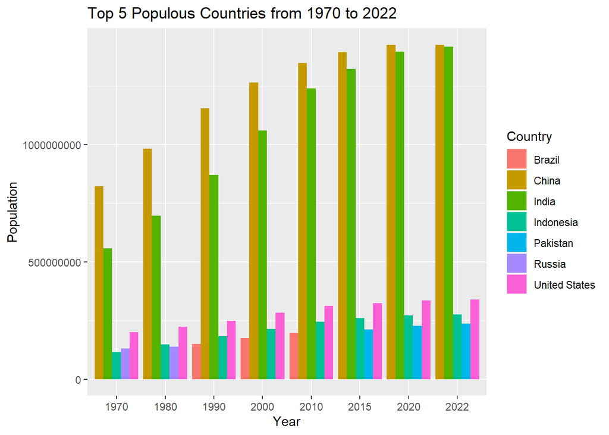

```r
ggplot(df1, aes(fill=Country, y=Population, x=Year)) +
  geom_bar(position='dodge', stat='identity') +
  ggtitle ('Top 5 Populous Countries from 1970 to 2022')
```

Then, we extract the least five countries by population from 1970 to 2022.

```r
# 2. Top 5 populous countries in 1970, 1980, 1990, 2000, 2010, 2015, 2020 and 2022.
df2 <- df
colnames(df2) <- c('Rank', 'CCA3', 'Country','Capital','Continent','2022',
                  '2020','2015','2010',
                  '2000','1990','1980',
                  '1970','Area', 'Density', 'Growth_Rate',
                  'World_Population_Percentage')

df2 <- df2 %>% select(c('Country','2022','2020',
                       '2015','2010',
                      '2000','1990',
                      '1980','1970')) %>% pivot_longer(cols=c('2022','2020',
                       '2015','2010',
                      '2000','1990',
                      '1980','1970'),
                      names_to = 'Year', values_to = 'Population') %>%
  arrange(Population) %>%
  group_by(Year) %>%
  slice(1:5)
head(df2, 10)
```

```
## # A tibble: 10 × 3
## # Groups:   Year [2]
##    Country          Year  Population
##    <chr>            <chr>      <int>
##  1 Vatican City     1970         752
##  2 Tokelau          1970        1714
##  3 Falkland Islands 1970        2274
##  4 Saint Barthelemy 1970        2417
##  5 Niue             1970        5185
##  6 Vatican City     1980         733
##  7 Tokelau          1980        1647
##  8 Falkland Islands 1980        2240
##  9 Saint Barthelemy 1980        2983
## 10 Niue             1980        3637
```

The method I use to create a bar plot is similar to the previous question, it shows the population of the five least populous countries from 1970 to 2022.

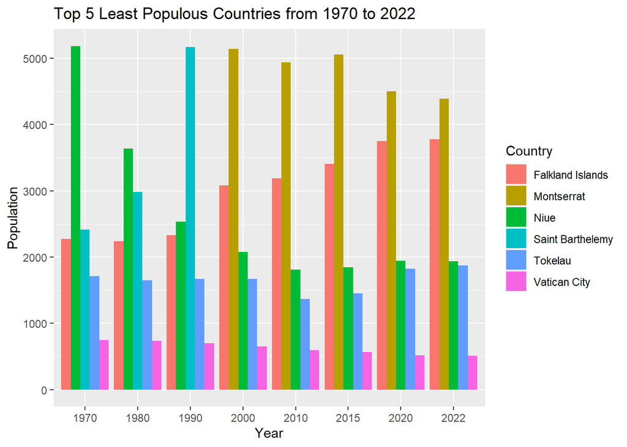

```r
ggplot(df2, aes(fill=Country, y=Population, x=Year)) +
  geom_bar(position='dodge', stat='identity') +
  ggtitle ('Top 5 Least Populous Countries from 1970 to 2022')
```

We can conclude that the population of Niue began to decrease from 1970 until 2010, and then increased a little. Montserrat is gaining momentum, starting in 2000 as the most populous of the five least populated countries, but Falkland Island has been growing as well.

Next, we look at the population growth rate for top 5 countries.

As described above, although China’s population is currently the largest in the world, India is gaining momentum. Is it possible to surpass China and become the next country with the largest population in the world?

```r
# 3. growth rate of the 5 most populous countries
df3 <- df1 %>% filter(Year == 2022)
df_tmp <- df %>% select(c('Country','Growth_Rate'))
df3 <- merge(df3, df_tmp, by='Country', all.x=TRUE) %>% select(c('Country','Population','Growth_Rate')) %>% arrange(desc(Population))
df3
```

```
##         Country Population Growth_Rate
## 1         China 1425887337      1.0000
## 2         India 1417173173      1.0068
## 3 United States  338289857      1.0038
## 4     Indonesia  275501339      1.0064
## 5      Pakistan  235824862      1.0191
```

From the data, the China has the least population growth rate and Pakistan has the highest population growth rate. Based on India’s growth rate of 1.0068 is higher than China’s growth rate of 1.0000, and the population until 2022, we expect India’s population will have more than China’s population.

Using the data `df3` obtained above, make a visualization to observe the population and growth trends of the top five countries in the world.

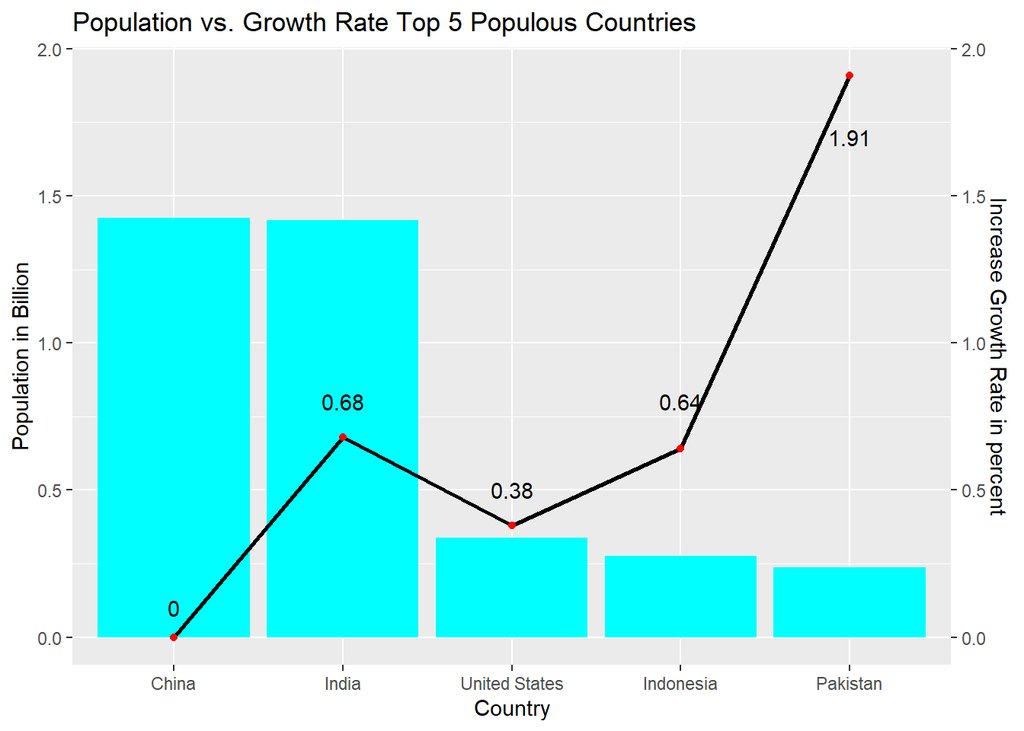

```r
ggplot(df3, aes(x=reorder(Country, +desc(Population))))  +
  geom_bar(aes(y=Population*0.000000001, group=1),stat="identity", fill="cyan") +
  geom_line(aes(y=(Growth_Rate-1)*100, group=1),stat="identity",color="black",size=1)+
  scale_y_continuous(name = 'Population in Billion', sec.axis=sec_axis(trans = ~.*1, name="Increase Growth Rate in percent")) +
  labs(title= "Population vs. Growth Rate Top 5 Populous Countries", x = 'Country') +
  geom_point(aes(y=(Growth_Rate-1)*100, group=1), col='red') +
  geom_text(x=c(1,2,3,4,5), y = c(0.1, 0.8, 0.5, 0.8, 1.7), label=c(0, 0.68, 0.38, 0.64, 1.91))
```

To better visualize the growth rate, we changed population growth rate to increase of growth rate in percentage,for example, India’s growth rate is 1.0068, so the increase of growth rate is 0.68%.

From the plot, Pakistan has the highest increase of growth rate 1.91%. China has a increase of growth rate 0% in recent years, while India has a increase of growth rate 0.68%. If maintains, India’s population will surpass that of China.

Then, we look at the comparison of population density. First look at the five countries with the lowest population density.

```r
# 4. The 5 countries with the least population density
df4 <- df %>% arrange(Density) %>% slice(1:5) %>% select(c("Country","Population_2022", "Density"))
df4
```

```
##            Country Population_2022 Density
## 1        Greenland           56466  0.0261
## 2 Falkland Islands            3780  0.3105
## 3   Western Sahara          575986  2.1654
## 4         Mongolia         3398366  2.1727
## 5          Namibia         2567012  3.1092
```

From the data, we know Greenland, Falkland Islands, Western Sahara, Mongolia and Namibia has the least population density.

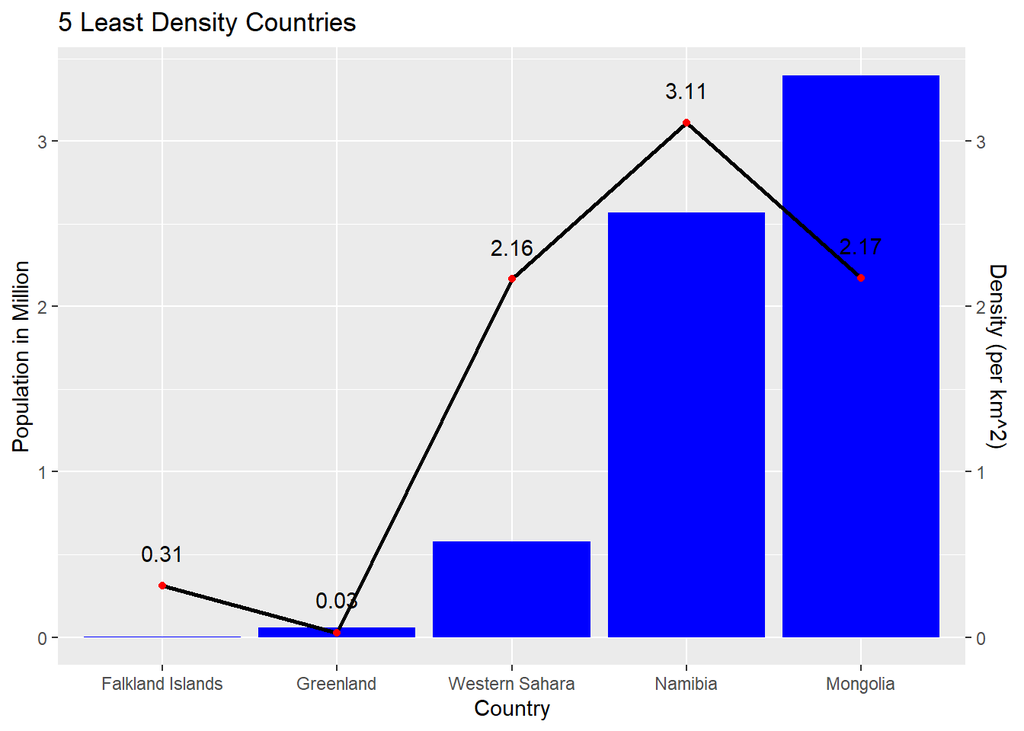

```r
ggplot(df4, aes(x=reorder(Country, +Population_2022)))  +
  geom_bar(aes(y=Population_2022*0.000001, group=1),stat="identity", fill="blue") +
  geom_line(aes(y=Density, group=1),stat="identity",color="black",size=1)+
  scale_y_continuous(name = 'Population in Million', sec.axis=sec_axis(trans = ~.*1, name="Density (per km^2)")) +
  labs(title= "5 Least Density Countries", x= 'Country') +
  geom_point(aes(y=Density, group=1), col='red') +
  geom_text(x=c(1,2,3,4,5), y = c(0.51,0.23,2.36,3.31,2.37), label=c(0.31,0.03,2.16,3.11,2.17))
```

From the figure, the blue bars represents the population and the line represents the population density. Of the five countries, Namibia has the highest population density of 3.11$(people/km^2)$ and Greenland has the lowest of 0.03$(people/km^2)$.

Next, we look at the population growth rate for 5 countries with least density.

```r
# Growth rate of the 5 least densely populated countries
df5 <- df %>% arrange(Density) %>% slice(1:5) %>% select(c("Country", "Density", "Growth_Rate"))
df5
```

```
##            Country Density Growth_Rate
## 1        Greenland  0.0261      1.0040
## 2 Falkland Islands  0.3105      1.0043
## 3   Western Sahara  2.1654      1.0184
## 4         Mongolia  2.1727      1.0151
## 5          Namibia  3.1092      1.0146
```

From the data, the Greenland has the least population growth rate and Western Sahara has the highest population growth rate.

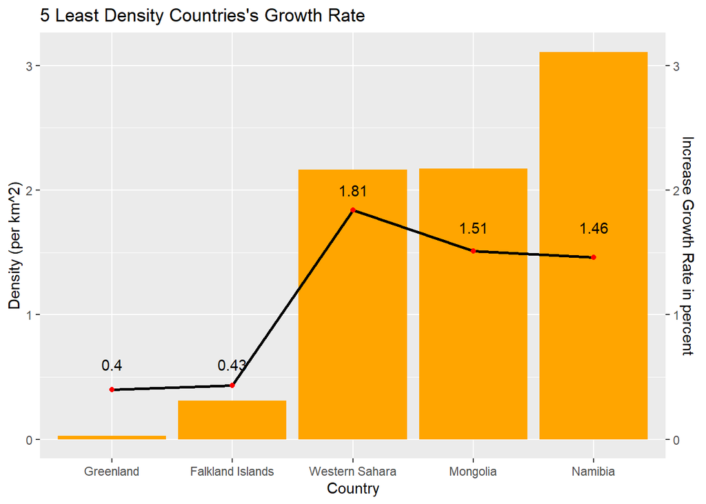

```r
ggplot(df5, aes(x=reorder(Country, +Density)))  +
  geom_bar(aes(y=Density, group=1),stat="identity", fill="orange") +
  geom_line(aes(y=(Growth_Rate-1)*100, group=1),stat="identity",color="black",size=1)+
  scale_y_continuous(name = 'Density (per km^2)', sec.axis=sec_axis(trans = ~.*1, name="Increase Growth Rate in percent")) +
  labs(title= "5 Least Density Countries's Growth Rate", x = "Country") +
  geom_point(aes(y=(Growth_Rate-1)*100, group=1), col='red') +
  geom_text(x=c(1,2,3,4,5), y = c(0.6,0.6,2,1.7,1.7), label=c(0.4,0.43,1.81,1.51,1.46))
```

From the plot, the Western Sahara has the highest increase population growth rate of 1.81%, and the Greenland has the lowest increase population growth rate of 0.4%. comparing to the countries with large population and high density, the increase of growth rate of these low density countries are the similar.

Then, Let’s focus on the proportion of the population of different continents in the world from 1970 to 2022.

```r
# 6. Population distribution by continent
df6 <- df

df6 <- df6 %>% select(c('Continent','Population_2022','Population_2020',
                       'Population_2015','Population_2010',
                      'Population_2000','Population_1990',
                      'Population_1980','Population_1970')) %>% group_by(Continent) %>%
  summarise(sum_2022 = sum(Population_2022),
            sum_2020 = sum(Population_2020),
            sum_2015 = sum(Population_2015),
            sum_2010 = sum(Population_2010),
            sum_2000 = sum(Population_2000),
            sum_1990 = sum(Population_1990),
            sum_1980 = sum(Population_1980),
            sum_1970 = sum(Population_1970))

colnames(df6) <- c('Continent', '2022',
                  '2020','2015','2010',
                  '2000','1990','1980',
                  '1970')

df6 <- df6 %>% pivot_longer(cols=c('2022','2020',
                       '2015','2010',
                      '2000','1990',
                      '1980','1970'),
                      names_to = 'Year', values_to = 'Population') %>%
  arrange(Continent, Year)
df6[['Year']] <- as.numeric(df6[['Year']])
```

This time we use a line chart to do this visualization.

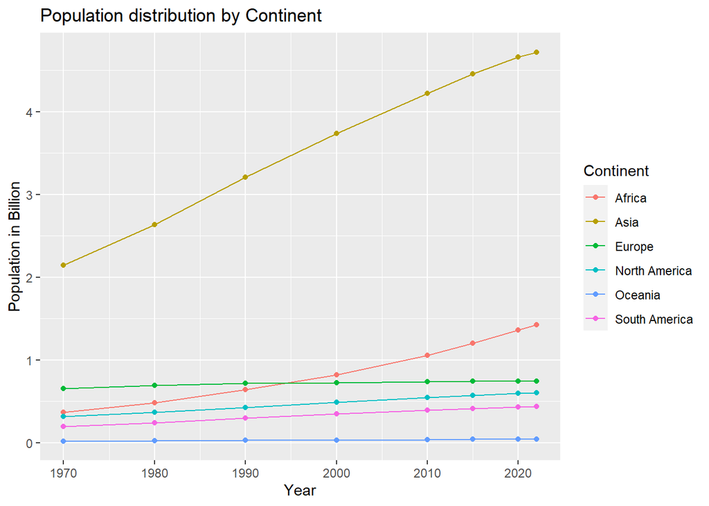

```r
ggplot(data = df6, aes(x=Year)) +
  geom_line(aes(y=Population / 1000000000, colour=Continent)) +
  geom_point(aes(y=Population / 1000000000, colour=Continent)) +
  labs(title= "Population distribution by Continent", y = "Population in Billion")
```

In the plot,Asia’s population grows fast continuously form 1970s to 2022. And its population is much more than other continents.The other continent that has obvious population growth trend is Africa. Compare to Asia and Africa, other continents do not have a big growth throughout the years. The population of Oceania is the smallest of all continents, and the growth rate is also very small.

Then, Let’s look at the population density of each of these continents.

```r
# 7. Population density of each continent

df7 <- df

df7 <- df7 %>% select(c('Continent','Population_2022','Population_2020',
                       'Population_2015','Population_2010',
                      'Population_2000','Population_1990',
                      'Population_1980','Population_1970', 'Area')) %>% group_by(Continent) %>%
  summarise(density_2022 = sum(Population_2022) / sum(Area),
            density_2020 = sum(Population_2020) / sum(Area),
            density_2015 = sum(Population_2015) / sum(Area),
            density_2010 = sum(Population_2010) / sum(Area),
            density_2000 = sum(Population_2000) / sum(Area),
            density_1990 = sum(Population_1990) / sum(Area),
            density_1980 = sum(Population_1980) / sum(Area),
            density_1970 = sum(Population_1970) / sum(Area))

colnames(df7) <- c('Continent', '2022',
                  '2020','2015','2010',
                  '2000','1990','1980',
                  '1970')

df7 <- df7 %>% pivot_longer(cols=c('2022','2020',
                       '2015','2010',
                      '2000','1990',
                      '1980','1970'),
                      names_to = 'Year', values_to = 'Density') %>%
  arrange(Continent, Year)
df7[['Year']] <- as.numeric(df7[['Year']])
```

Through the above calculation and classification, visualization can now be made.

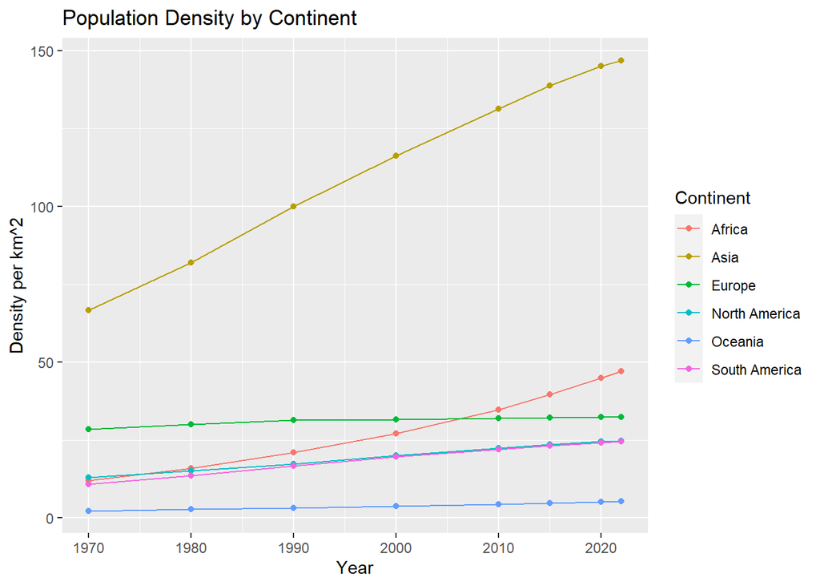

```r
ggplot(data = df7, aes(x=Year)) +
  geom_line(aes(y=Density, colour=Continent)) +
  geom_point(aes(y=Density, colour=Continent)) +
  labs(title= "Population Density by Continent", y = "Density per km^2")
```

By comparing population trend and population density trend from 1970 to 2020, we find the two trend shares the same pattern.

Finally, we are interest in the land area of countries. The following distribution is the largest 5 countries and the smallest 5 countries.

```r
# Five largest countries
df8 <- df %>% arrange(desc(Area)) %>% slice(1:5) %>% select(c("Country", "Area"))
df8
```

```
##         Country     Area
## 1        Russia 17098242
## 2        Canada  9984670
## 3         China  9706961
## 4 United States  9372610
## 5        Brazil  8515767
```

The Largest country is Russia, the Area is 17098242 $km^2$.

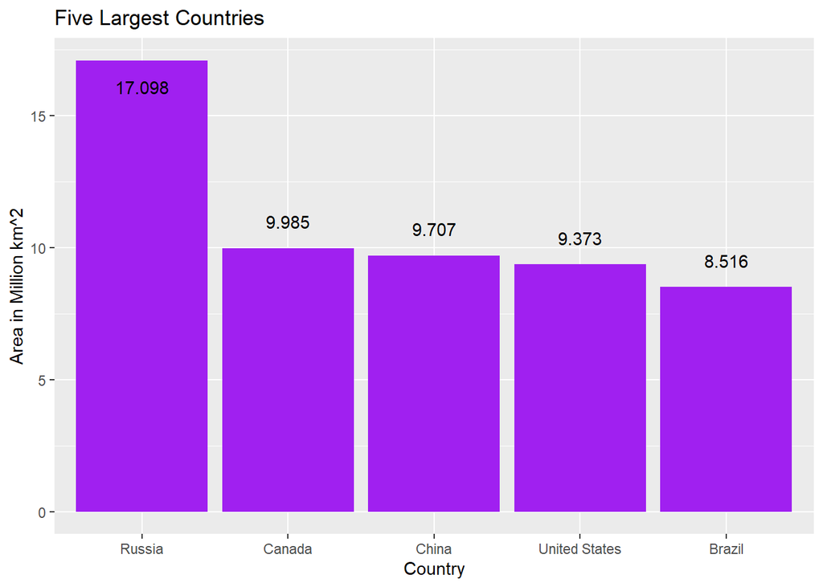

```r
ggplot(df8, aes(x=reorder(Country, +desc(Area))))  +
  geom_bar(aes(y=Area/1000000, group=1),stat="identity", fill="purple") +
  geom_text(x=c(1,2,3,4,5), y = c(16.098,10.985,10.707,10.373,9.516), label=c(17.098,9.985,9.707,9.373,8.516)) +
  labs(title= "Five Largest Countries", y = "Area in Million km^2",
        x = 'Country')
```

In the visualization, Russia is shown to have the largest area, roughly twice the size of Brazil, which ranks fifth. The area gap between Canada, China and the United States, which ranks second to fourth, is relatively small.

```r
# Five smallest countries
df9 <- df %>% arrange(Area) %>% slice(1:5) %>% select(c("Country", "Area"))
df9
```

```
##        Country Area
## 1 Vatican City    1
## 2       Monaco    2
## 3    Gibraltar    6
## 4      Tokelau   12
## 5        Nauru   21
```

The smallest country is Vatican City, and it’s area is 1$km^2$.

[figure not shown]

```r
ggplot(df9, aes(x=reorder(Country, +Area)))  +
  geom_bar(aes(y=Area, group=1),stat="identity", fill="brown") +
  geom_text(x=c(1,2,3,4,5), y = c(2,3,7,13,20), label=c(1,2,6,12,21)) +
  labs(title= "Five Smallest Countries", y = "Area in Million km^2",
        x = 'Country')
```

In the visualization, the Vatican is shown to have the smallest area at 1$km^2$, about the size of a square. The largest of them, Nauru, is only 21$km^2$.

## Data split & cross validation

For model training, we only keep the relevant features, including all the previous year’s population, area, and continent. We delete features such as density and growth rate because they can be used to calculate population of 2022 directly (correlation is almost 1).

The data was split in 70% training, 30% testing split. Stratified sampling was used as the `Continent`.

```r
# keep only the relevant variables
data <- df %>% select(c(Continent, Area, Population_1970,
                        Population_1980, Population_1990, Population_2000,
                        Population_2010, Population_2015, Population_2020,
                        Population_2022))
head(data)
```

```
##   Continent    Area Population_1970 Population_1980 Population_1990
## 1      Asia  652230        10752971        12486631        10694796
## 2    Europe   28748         2324731         2941651         3295066
## 3    Africa 2381741        13795915        18739378        25518074
## 4   Oceania     199           27075           32886           47818
## 5    Europe     468           19860           35611           53569
## 6    Africa 1246700         6029700         8330047        11828638
##   Population_2000 Population_2010 Population_2015 Population_2020
## 1        19542982        28189672        33753499        38972230
## 2         3182021         2913399         2882481         2866849
## 3        30774621        35856344        39543154        43451666
## 4           58230           54849           51368           46189
## 5           66097           71519           71746           77700
## 6        16394062        23364185        28127721        33428485
##   Population_2022
## 1        41128771
## 2         2842321
## 3        44903225
## 4           44273
## 5           79824
## 6        35588987
```

```r
# initial train test split
pop_split <- initial_split(data, strata = Continent, prop = 0.7)
pop_split
```

```
## <Training/Testing/Total>
## <162/72/234>
```

```r
pop_train <- training(pop_split)
pop_test <- testing(pop_split)
# 5 fold cross validation
pop_folds <- vfold_cv(pop_train, v = 5)
```

## Model Building

Steps we use to build and analysis the model:

1. Build the recipe and workflow for each of the model.
2. Use cross validation to tune the model parameters, and find the best parameter for the model.
3. Use the best parameters found in step2, fit the model on test set and calculate model performance.
4. Compare the performance for each model. Find the best model in the four models.

### Building the Recipe

set up preprocess recipe for all models.

```r
recipe <-
  recipe(formula = Population_2022 ~ ., data = pop_train) %>%
  step_novel(all_nominal_predictors()) %>%
  step_dummy(all_nominal_predictors()) %>%
  step_zv(all_predictors()) %>%
  step_normalize(all_predictors())
```

## Repeated cross-validation for preparing and running the model

After many considerations, I decided to perform repeated cross-validation on the following four models.

1. Ridge Regression
2. Lasso Regression
3. Regression Tree
4. Random Forest

### Ridge Regression

Loaded the required object that I saved in my script, set `mode` to `"regression"`,tuned `penality`, and used the `glmnet` engine. I stored this model and `recipe` in workflow.

```r
set.seed(1234)
ridge_spec <- linear_reg(mixture = 0, penalty = tune()) %>%
  set_mode("regression") %>%
  set_engine("glmnet")

ridge_workflow <- workflow() %>%
  add_recipe(recipe) %>%
  add_model(ridge_spec)
```

Next, I set up the adjustment grid and updated the penalty parameters. I tune the penalty, in the range of $-10$ to $10$ with the level $50$.

```r
ridge_penalty_grid <- grid_regular(penalty(range = c(-10, 10)), levels = 50)

ridge_tune_res <- tune_grid(
  ridge_workflow,
  resamples = pop_folds,
  grid = ridge_penalty_grid)
```

### Lasso Regression

In a similar process, I set the model with tuning parameter penalty. Set the engine as glmnet and created a workflow.

The difference between Lasso Regression and Ridge Regression is Lasso regression ’s mixture parameter equals 1 and Ridge regression’s mixture parameter equals 0. This differs the two models from $L1$ to $L2$.

```r
set.seed(1234)
lasso_spec <-
  linear_reg(penalty = tune(), mixture = 1) %>%
  set_mode("regression") %>%
  set_engine("glmnet")

lasso_workflow <- workflow() %>%
  add_recipe(recipe) %>%
  add_model(lasso_spec)
```

Next, set up the adjustment grid and updated the parameters. Tune the penalty, in the range of $-10$ to $10$ with the level $50$.

```r
lasso_penalty_grid <- grid_regular(penalty(range = c(-10, 10)), levels = 50)

lasso_tune_res <- tune_grid(
  ridge_workflow,
  resamples = pop_folds,
  grid = lasso_penalty_grid)
```

### Regression Tree

In this process, Set `mode` to `"regression"` and used the `rpart` engine. Stored this model and `recipe` in workflow.

```r
set.seed(1234)
reg_tree_spec <- decision_tree() %>%
  set_engine("rpart") %>%
  set_mode("regression")

reg_tree_wf <- workflow() %>%
  add_recipe(recipe) %>%
  add_model(reg_tree_spec %>% set_args(cost_complexity = tune()))
```

As above, Set up the adjustment grid and updated the parameters. Tune the cost complexity, in the range of -10 to -1 with the level 50.

```r
reg_tree_param_grid <- grid_regular(cost_complexity(range = c(-10, -1)), levels = 50)

reg_tree_tune_res <- tune_grid(
  reg_tree_wf,
  resamples = pop_folds,
  grid = reg_tree_param_grid
)
```

```
## ! Fold1: internal: A correlation computation is required, but `estimate` is constant and ha...
```

### Random Forest

```r
set.seed(1234)
rf_spec <- rand_forest(mtry = tune()) %>%
  set_engine("randomForest", importance = TRUE) %>%
  set_mode("regression")

rf_wf <- workflow() %>%
  add_recipe(recipe) %>%
  add_model(rf_spec)
```

```r
rf_grid <- grid_regular(parameters(rf_spec) %>%
 update(mtry = mtry(range= c(1, 9))), levels = 9)
rf_tune_res <- tune_grid(
  rf_wf,
  resamples = pop_folds,
  grid = rf_grid
)
```

## Repeated Cross Validation Model Analysis

### Ridge Regression

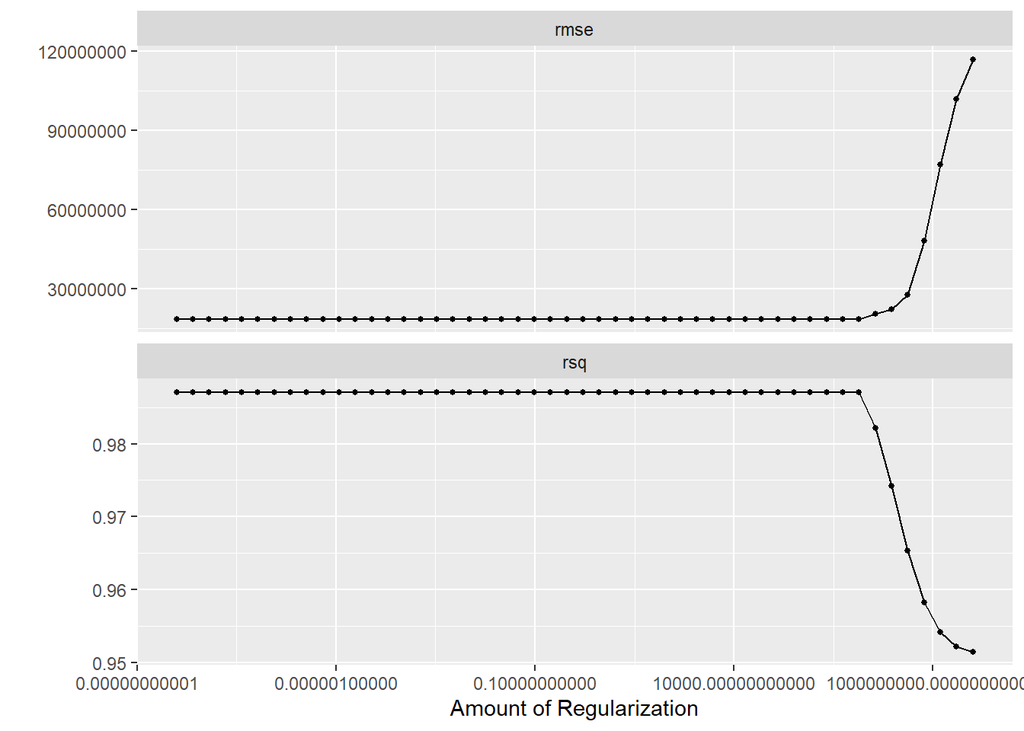

```r
autoplot(ridge_tune_res)
```

```r
ridge_best <- select_best(ridge_tune_res, metric = "rsq")
ridge_best
```

```
## # A tibble: 1 × 2
##        penalty .config
##          <dbl> <chr>
## 1 0.0000000001 Preprocessor1_Model01
```

Using the `select_best()` function, the best value of penalty is 1e-10.

### Lasso Regression

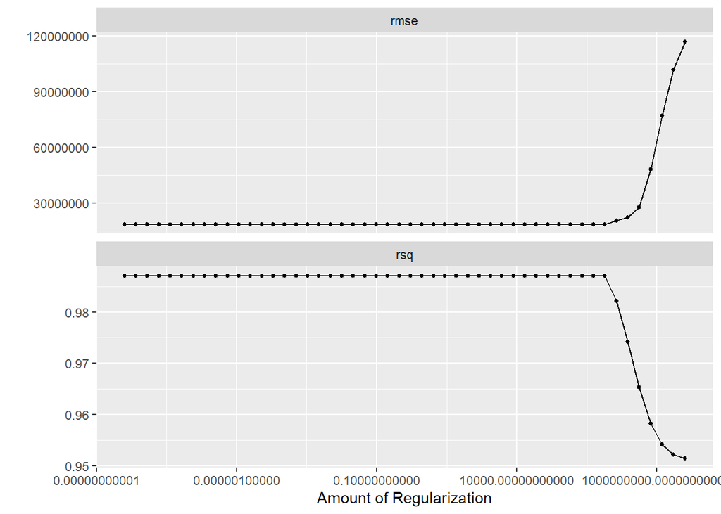

```r
autoplot(lasso_tune_res)
```

```r
lasso_best <- select_best(lasso_tune_res, metric = "rsq")
lasso_best
```

```
## # A tibble: 1 × 2
##        penalty .config
##          <dbl> <chr>
## 1 0.0000000001 Preprocessor1_Model01
```

Also using the `select_best()` function, the best value of penalty is 1e-10.

### Regression Tree

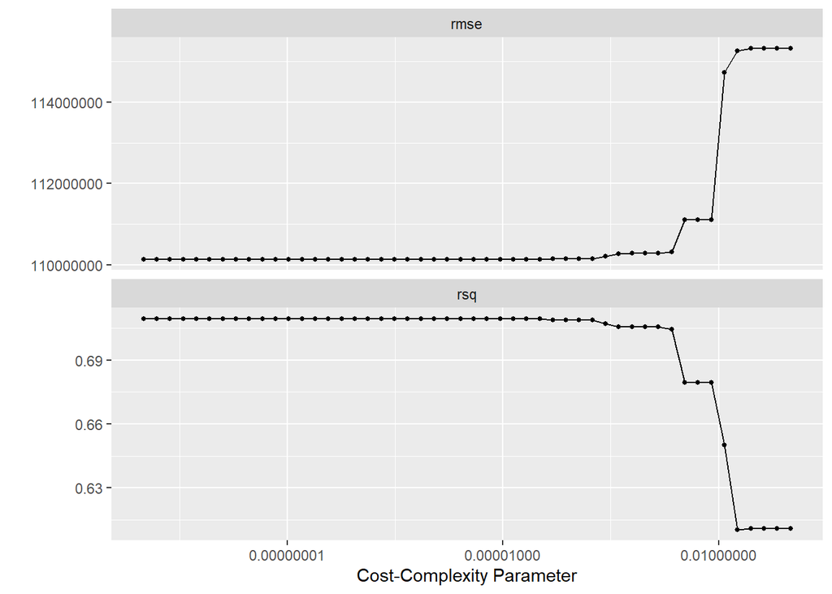

```r
autoplot(reg_tree_tune_res)
```

```r
reg_tree_best <- select_best(reg_tree_tune_res, metric = "rmse")
reg_tree_best
```

```
## # A tibble: 1 × 2
##   cost_complexity .config
##             <dbl> <chr>
## 1    0.0000000001 Preprocessor1_Model01
```

As same before, using the `select_best()` function, the best value of cost complexity is 1e-10.

### Random Forest

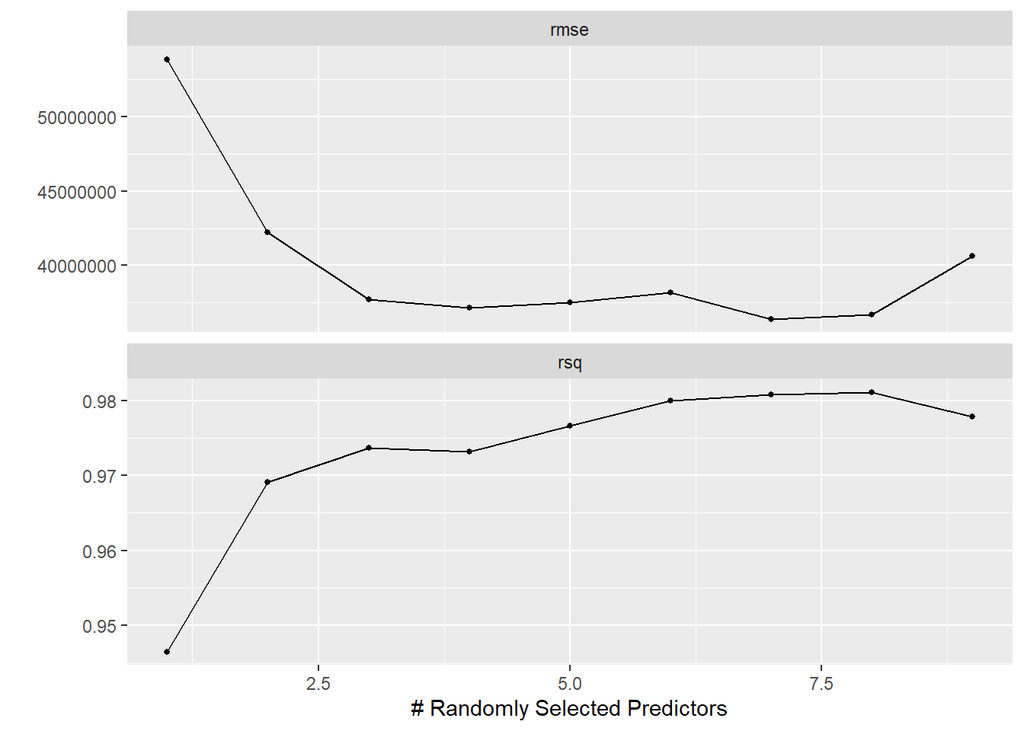

```r
autoplot(rf_tune_res)
```

```r
rf_best <- select_best(rf_tune_res, metric = "rmse")
rf_best
```

```
## # A tibble: 1 × 2
##    mtry .config
##   <int> <chr>
## 1     7 Preprocessor1_Model7
```

## Final Model Building

Create a workflow with an adjusted name so I can identify it. Use the $fit()$ function for each model to run the models on the test set and find the best model by comparing r squared value.

### Ridge Regression

```r
ridge_final <- finalize_workflow(ridge_workflow, ridge_best)
ridge_final_fit <- fit(ridge_final, data = pop_train)
augment(ridge_final_fit, new_data = pop_test) %>%
  rsq(truth = Population_2022, estimate = .pred)
```

```
## # A tibble: 1 × 3
##   .metric .estimator .estimate
##   <chr>   <chr>          <dbl>
## 1 rsq     standard       0.985
```

### Lasso Regression

```r
lasso_final <- finalize_workflow(lasso_workflow, lasso_best)
lasso_final_fit <- fit(lasso_final, data = pop_train)
augment(lasso_final_fit, new_data = pop_test) %>%
  rsq(truth = Population_2022, estimate = .pred)
```

```
## # A tibble: 1 × 3
##   .metric .estimator .estimate
##   <chr>   <chr>          <dbl>
## 1 rsq     standard       0.999
```

### Regression Tree

```r
reg_tree_final <- finalize_workflow(reg_tree_wf, reg_tree_best)
reg_tree_final_fit <- fit(reg_tree_final, data = pop_train)
#reg_tree_final_fit %>%
  #extract_fit_engine() %>%
  #rpart.plot()
augment(reg_tree_final_fit, new_data = pop_test) %>%
  rsq(truth = Population_2022, estimate = .pred)
```

```
## # A tibble: 1 × 3
##   .metric .estimator .estimate
##   <chr>   <chr>          <dbl>
## 1 rsq     standard       0.820
```

### Random Forest

```r
rf_final <- finalize_workflow(rf_wf, rf_best)
rf_final_fit <- fit(rf_final, data = pop_train)
augment(rf_final_fit, new_data = pop_test) %>%
  rsq(truth = Population_2022, estimate = .pred)
```

```
## # A tibble: 1 × 3
##   .metric .estimator .estimate
##   <chr>   <chr>          <dbl>
## 1 rsq     standard       0.961
```

By comparison, Lasso Regression is the best model because it’s r squared value is the largest.

Compare the predictions of the four models across countries, actual values, and append them into a data frame for comparison.

```r
# append country, actual value, predict result from 4 models together in one data frame
data_pred_result <- df %>% select('Country', 'Population_2022')

data_pred_result['reg_tree_pred'] <- augment(reg_tree_final_fit, new_data = data)['.pred']

data_pred_result['rf_pred'] <- augment(rf_final_fit, new_data = data)['.pred']

data_pred_result['ridge_pred'] <- augment(ridge_final_fit, new_data = data)['.pred']

data_pred_result['lasso_pred'] <- augment(lasso_final_fit, new_data = data)['.pred']

data_pred_result
```

```
##                              Country Population_2022 reg_tree_pred
## 1                        Afghanistan        41128771  36266828.583
## 2                            Albania         2842321   3095025.833
## 3                            Algeria        44903225  36266828.583
## 4                     American Samoa           44273     48422.357
## 5                            Andorra           79824     48422.357
## 6                             Angola        35588987  36266828.583
## 7                           Anguilla           15857      8858.556
## 8                Antigua and Barbuda           93763    124070.417
## 9                          Argentina        45510318  36266828.583
## 10                           Armenia         2780469   3095025.833
## 11                             Aruba          106445    124070.417
## 12                         Australia        26177413  21432754.000
## 13                           Austria         8939617  10543885.526
## 14                        Azerbaijan        10358074  10543885.526
```

[output cut: 455 more lines]

From the Table, In many countries, the model predictions are quite different from the actual values. For example, the actual value of American Samoa’s population is 44273, but its Lasso Regression prediction result is 1507434; the actual population value of Anguilla is 15857, but its Lasso Regression prediction result is 1476729. These predictions are much larger than actual values, so the predictions are not accurate.

## Conclusion

Through research, testing and analysis, Lasso Regression performed best in my models, Ridge Regression and Random forest are not bad, and Regression Tree did not perform well. Although the value of the r squared value of Lasso Regression, Random Forest and Ridge Regression is very close to 1, there is still a gap between the prediction results of many countries and their real population values. Because a lot of factors such as people’s life expectancy, fertility rate and death rate are all related to population growth, there is no way to predict the exact future world population.

In addition, the regression models has its limitation that it predicts a similar pattern for each continents or level of size of countries. However, from EDA at the beginning, even in the same continent or shares the similar value of areas, the country’s growth rate differs. Therefore, for future research I propose to find more features to improve our model, such that gross national happiness index, and GDP, etc. We can also try more complicated models such as neuro network model.

Overall, this World Population Modeling project provided me with a great opportunity to gain experience and improve my skills through data analysis and machine learning techniques.